# The Blog Post

Author

Amanda Overbye

Published

March 13, 2025

```r
# Load packages
library(tidycensus)
library(tidyverse)
library(ggplot2)
library(tmap)
library(here)
library(janitor)
library(usdata)
library(tigris)
library(sf)
library(scales)
library(airportr)
library(ggmap)
library(maps)
library(patchwork)
library(lubridate)
library(gridExtra)
library(ggalluvial)
library(geosphere)
library(waffle)
library(showtext)
library(ggbump)
```

# Creating an infographic using R data visualizations to answer questions about Air freight shipping.

I have been watching airplanes fly by all of my life. I have always found myself looking at the airplanes and wondering who or what is on those airplanes. I have been ordering stuff online for all of my adult life. I realize that the majority of items I order do not come from nearby and probably have undergone their own journeys to arrive in possession.

As a student in the Masters in Environmental Data Science program at the University of California Santa Barbara, I was given the opportunity to create some data visualizations on any topic of my choosing so I decided I would answer my mostly life long question about airplanes and shipping. I mainly wanted to know where are planes coming from and going to? How much do we actually ship via freight? How has this changed over time? This is a guide on how I created the visuals I used to answer these questions.

# Defintions and Background

### Background on data

The data I am using comes from the department of transportation. Specifically, I used the [Air Carriers : T-100 International Segment for US carriers only data](https://www.transtats.bts.gov/Fields.asp?gnoyr_VQ=GDK). This data set contains information about all flights that are flying to and from the United States from international areas. The main variable I was interested in were those in regards to the amount of freight in pounds transported, and the departure and destination information. While the data included the International Air Transport Association, a 3 letter code given to airports based on location, it lacked any coordinate information. To gain the coordinate information, I used the airportr package and then combined the datasets.

### Function for reading in data

```r
# Function for reading in CSVs
read <- function(year) {
  file_name <- paste0("flights", year, ".csv")
  file_path <- here("data", file_name)

  # Read and filter dataset
  df <- read.csv(file_path) %>%
    filter(FREIGHT != 0) %>%
    clean_names()

  return(df)
}
```

### Reading in the data via the function

```r
# Read in data via function

freight2024 <- read(2024)
freight2023 <- read(2023)
freight2022 <- read(2022)
freight2021 <- read(2021)
freight2020 <- read(2020)
freight2019 <- read(2019)
freight2018 <- read(2018)
freight2017 <- read(2017)
freight2016 <- read(2016)
freight2015 <- read(2015)
freight2014 <- read(2014)
freight2013 <- read(2013)
freight2012 <- read(2012)
freight2011 <- read(2011)
freight2010 <- read(2010)
freight2009 <- read(2009)
freight2008 <- read(2008)
freight2007 <- read(2007)
freight2006 <- read(2006)
freight2005 <- read(2005)
freight2004 <- read(2004)
```

### Function to join dfs

```r
# Create function to join datasets
join_freight_data <- function(...) {
  Reduce(full_join, list(...))
}
```

### Joining the dfs via function

```r
# Use the function to join all datasets
freight_all <- join_freight_data(
  freight2004, freight2005, freight2006, freight2007,
  freight2008, freight2009, freight2010, freight2011,
  freight2012, freight2013, freight2014, freight2015,
  freight2016, freight2017, freight2018, freight2019,
  freight2020, freight2021, freight2022, freight2023,
  freight2024
)
```

### Reading in the air coords data

This data is not used for the rest of the code so I may add in the map section

```r
air_coords <- airports %>%
  clean_names()
```

# The Map

The first visualization I wanted to create was a map showing which airports had the largest amount of pounds traveling between them. While the map adequetly visualized the the connections between the airports, it should be noted that it does not accuretly show the route the planes took. For example, a plane flying from Ankorage Alaska to South Korea is most likely going to fly over the pacific ocean, not over the Atlantic, Africa and the rest of Asia.

### Data cleaning and combining for the map

```r
# Rename origin and dest columns
freight_map_data <- freight_all %>%
  rename(iata_origin = origin) %>%
  rename(iata_dest = dest)
```

```r
# Duplicating iata coloumn
air_coords$iata_origin = air_coords$iata

# Renaming original iata column
air_coords_rn <- air_coords %>%
  rename(iata_dest = iata)
```

```r
# Duplicate and rename lat longs
air_coords_rn$lat_dest = air_coords_rn$latitude
air_coords_rn$long_dest = air_coords_rn$longitude
```

```r
# Rename original lat longs
air_duocoords <- air_coords_rn %>%
  rename(lat_origin = latitude) %>%
  rename(long_origin = longitude)
```

### Joining the data

This is where I joined the edited freight data with the airport coordinate data.

```r
# Join freight_all with air_duocoords to get destination coordinates
freight_coords <- freight_map_data %>%
  left_join(air_duocoords %>%
              select(iata_dest, lat_dest, long_dest),
            by = "iata_dest") %>%
  # Join again to get origin coordinates
  left_join(air_duocoords %>%
              select(iata_origin, lat_origin, long_origin),
            by = "iata_origin")
```

### Refining the data for the map

Before I could actually create the map, I had to get the data for the for the locations that had the most amount of freight in pounds traveling between them. I began by using the group_by dplyr function to tell the program that I wanted all the rows where freight was shipped between the same two airports to be treated as a single when I went to count the pounds of freight and create a new column for it using the mutate function. By using the distinct function, I was able to have only one row for each origin and destination combination, therefore avoiding having duplicates with the same amount of freight pounds at the end.

```r
airport_routes <- freight_coords %>%
  group_by(iata_origin, iata_dest) %>%
  mutate(freight_shipped = sum(freight, na.rm = TRUE)) %>%  # Sum freight shipped for each route
  ungroup() %>%  # Remove grouping after adding the freight count
  distinct(iata_origin, iata_dest, .keep_all = TRUE) %>%  # Keep only unique routes
  arrange(desc(freight_shipped))
```

```r
# Filtering for the top 20 routes
top_20_routes <- airport_routes %>%
  arrange(desc(freight_shipped)) %>%
  head(20)
```

### Plotting the map

To create the map, I used ggplot. I used geom_curve to ensure the lines between the airports were curved and not just straight.

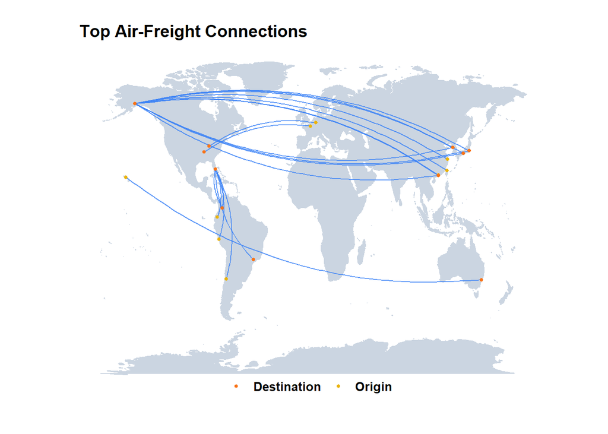

```r
# Define an aviation-themed color palette
aviation_pal <- c("#1E3A8A", "#3B82F6", "#60A5FA", "#93C5FD",
                  "#6366F1", "#EAB308", "#FACC15", "#F97316",
                  "#64748B", "#94A3B8", "#CBD5E1", "#E5E7EB")

# Get world map data
world_map <- map_data("world")

# Create ggplot
map_pounds <- ggplot() +
  # Add world map background with aviation theme
  geom_polygon(data = world_map, aes(x = long, y = lat, group = group),
               fill = "#CBD5E1", color = "#CBD5E1") +  # Light gray-blue for land with slightly darker borders

  # Add curved lines for routes
  geom_curve(data = top_20_routes,
             aes(x = long_origin, y = lat_origin,
                 xend = long_dest, yend = lat_dest),
             color = "#3B82F6",  # Medium blue for flight paths
             curvature = 0.2, size = .5, alpha = 0.8) +

  # Add points for origin airports
  geom_point(data = top_20_routes, aes(x = long_origin, y = lat_origin, color = "Origin"),
             size = 1) +

  # Add points for destination airports
  geom_point(data = top_20_routes, aes(x = long_dest, y = lat_dest, color = "Destination"),
             size = 1) +

  # Theme settings matching the bump chart style
  theme_minimal() +
  theme(axis.text = element_blank(),
        axis.ticks = element_blank(),
        panel.grid = element_blank(),

        legend.position = c(.48, .013),
        legend.justification = c("center"),
        legend.direction = "horizontal",
        legend.text = element_text(size = 10, face = "bold"),
        plot.title = element_text(size = 14, face = "bold"),
        plot.margin = margin(20, 50, 20, 50)
        ) +

  # Add the legend with colors from aviation palette
  scale_color_manual(values = c("Origin" = "#EAB308",  # Gold for origin points (resembles takeoff)
                                "Destination" = "#F97316"),  # Orange for destination points (resembles landing)
                     name = " ") +

  labs(title = "Top Air-Freight Connections",
       x = "", y = "")

# Store the plot in a variable
route_map <- map_pounds
route_map
```

I enjoy looking at the map and imagining which planes might be coming from different areas.

# The bump chart

The data I am using includes information from 2004 all the way to 2024. For the basic map made above, I used information from all the years. However, where things are coming from and going to has almost certainly changed over the past 20 years. This is where I thought using a bump chart could ergonicimally show how things have shifted over the past several years.

### Refining the data for the bump chart

The main hurdle I faced when doing this chart was deciding how I was going to tell the computer to separate the United States from other countries. While the map highlights origin and destination differences, I didn’t want to do that here. The question I wanted this chart to answer was purely about what other countries are on either end of the arrival or depature with the most pounds of freight.

I did this using the **ifelse** function. If the country name of the origin was equal to the “United States,” it tells the computer to use the destination country name. If the origin country is not equal to the United States, it tells the computer to use the origin name. This is how I told the computer to make a new column with the non-united states value. Once again, the summarize and sum functions were used to get the total amount of freight pounds. Lastly, I used the **group_by** function to tie tie the amount of freight to the year it was transported. For example, every year would have a row with “china” (or any other country), and the amount of freight transported there in the year.

```r
# Get the amount of freight based on the non us country
other_countries_col <- freight_all %>%
  mutate(other_country = ifelse(origin_country_name == "United States", dest_country_name, origin_country_name)) %>%
  group_by(other_country, year) %>%
  summarize(total_freight = sum(freight, na.rm = TRUE))
```

```r
# Rank the number one countries by year
country_rank_by_year <- other_countries_col %>%
  filter(year >= 2019) %>%
  select(year, other_country, total_freight) %>%
  group_by(year) %>%
  mutate(
    rank = row_number(desc(total_freight))
  ) %>%
  ungroup() %>%
  arrange(rank, year)
```

```r
# Filter for 2024
top_countries_2024 <- country_rank_by_year %>%
  filter(year == 2024, rank <= 10) %>%
  pull(other_country)
```

### Plotting the bump chart

The reasoning behind using a bump chart for this visualization is not only because it can display the information accurately, but also because it gives a sense of flow and travel. One of the key themes I want on my visualization is a sense of movement and forward flow.

```r
# Define an aviation-themed color palette
aviation_pal <- c("#1E3A8A", "#3B82F6", "#60A5FA", "#93C5FD",
                  "#6366F1", "#EAB308", "#FACC15", "#F97316",
                  "#64748B", "#94A3B8", "#CBD5E1", "#E5E7EB")
```

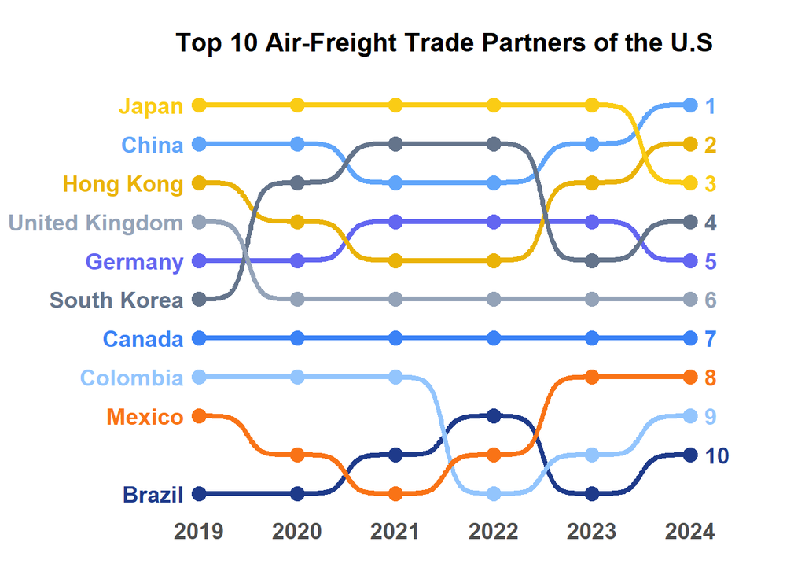

```r
ggplot(country_rank_by_year %>% filter(other_country %in% top_countries_2024),
       aes(x = year, y = rank, color = other_country)) +

  # Add smooth curved lines
  geom_bump(linewidth = 1.5) +

  # Add points for better visibility
  geom_point(size = 4) +

  # Left-side country labels (adjusted positioning)
  geom_text(
    data = country_rank_by_year %>% filter(year == 2019, other_country %in% top_countries_2024),
    aes(label = other_country),
    hjust = 1,
    nudge_x = -0.15,
    size = 5,
    fontface = "bold"
  ) +

  # Right-side rank labels (adjusted positioning)
  geom_text(
    data = country_rank_by_year %>% filter(year == 2024, other_country %in% top_countries_2024),
    aes(label = rank),
    hjust = 0,
    nudge_x = 0.15,
    size = 5,
    fontface = "bold"
  ) +

  # Reverse y-axis for ranking (1st place at the top)
  scale_y_reverse() +

  # Apply aviation color palette
  scale_color_manual(values = aviation_pal, guide = "none") +

  # Adjust boundaries to prevent cutoff
  coord_cartesian(xlim = c(2018.9, 2024.1), ylim = c(11, 0.5), clip = "off") +

  labs(title = "Top 10 Air-Freight Trade Partners of the U.S") +

  # Aesthetic improvements
  theme_minimal() +
  theme(
    panel.grid.major = element_blank(),
    panel.grid.minor = element_blank(),
    plot.title = element_text(size = 16, face = "bold", hjust = 0.5),
    axis.title = element_blank(),
    axis.text.y = element_blank(),
    axis.text.x = element_text(size = 14, face = "bold"),
    legend.position = "none",
    plot.margin = margin(20, 50, 20, 100) # Increased margins
  )
```

# Creating the timeline

After creating the bump chart, my next goal was to create a timeline that showed how the amount of freight in pounds has changed over the past 20 years. When I was thinking of how to put all of the elements together, I originally wanted the bump chart and the timeline to focus on the same amount of years. However, when I lengthened the timeframe of the bump chart, the information got harder to follow and it lost its use in conveying information. When I tried to shorten the timeline, certain events like the freight recession, became less noticable. Ultimetly, I decided it was better and more interesting if the plots focused on different years.

### Refining the data for the timeline

The data for the timeline was the easiest to handle because all I really needed to do was ensure thaqt the date-time format was correct, then I could group and plot with ease.

```r
# Convert year and month into a proper date format
freight_all <- freight_all %>%
  mutate(date = make_date(year, month, 1))
```

```r
# Aggregate freight by month
freight_month <- freight_all %>%
  group_by(year, month) %>%
  summarise(total_freight = sum(freight, na.rm = TRUE), .groups = "drop") %>%
  mutate(date = make_date(year, month, 1))
```

### Plotting the timeline

Plotting the timeline involved making some of the harder visual decisions. I wanted to show the lines for each year, but I was afraid that would take away from the general cohesiveness of all the elements put together. Ultimately, I think it worked out but it was challenging for me to figure out how I could make it cohesive.

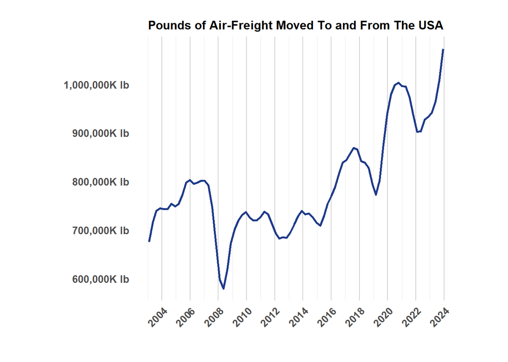

```r
timeline <-
  ggplot(freight_month, aes(x = date, y = total_freight)) +
  geom_smooth(color = "#1E3A8A", size = 1, span = 0.1, se = FALSE) +
  scale_x_date(date_labels = "%Y", date_breaks = "24 months") +
  scale_y_continuous(
    labels = scales::label_number(scale = 1e-3, suffix = "K lb", big.mark = ",")
  ) +
  labs(title = "Pounds of Air-Freight Moved To and From The USA",
       x = "",
       y = "") +
  theme_minimal() +
  theme(
    plot.title = element_text(size = 12, face = "bold", hjust = 0.5),  # Match bump chart title
    axis.text.x = element_text(size = 10, face = "bold", angle = 45, hjust = 1),
    axis.text.y = element_text(size = 10, face = "bold"),
    panel.grid.major.y = element_blank(),
    panel.grid.minor.y = element_blank(),
    panel.grid.major.x = element_line(color = "lightgray", linewidth = 0.5),
    plot.margin = margin(20, 50, 20, 50)  # Ensure proper spacing
  )

print(timeline)
```

# The final visuals

Once all those pieces were finished, I used google slides to put to final pieces together.

[figure not shown]

And that is how I made the pieces of this infographic